# Single-celled bottlenecks, germlines and the evolution of complex multi-cellularity

# 1 Pre-amble

## 1.1 load packages

```r
knitr::purl('germline_bayesian_analyses.Rmd','germline_bayesian_analyses.R') #read this rmd to an .R file
```

```
processing file: germline_bayesian_analyses.Rmd
```

[output not shown]

[output cut: 13 more lines]

```
output file: germline_bayesian_analyses.R
```

```
[1] "germline_bayesian_analyses.R"
```

```r
library(rotl) #see https://cran.r-project.org/web/packages/rotl/vignettes/rotl.html
```

# 1 Pre-amble

## 1.1 load packages

```r
library(ape)
library(ggplot2)
library(tidyverse)
library(knitr)
library(brms) #https://rdrr.io/cran/brms/f/vignettes/brms_phylogenetics.Rmd
library(tidybayes)
library(rotl) #see https://cran.r-project.org/web/packages/rotl/vignettes/rotl.html
```

## 1.2 read in data

```r
df<- read.csv('data/germline_data_1.2.csv')
#create a genus column
df<- df %>%
  separate(species.updated.rotl, into = c('genus', 'species'), remove = F)
glimpse(df)
```

```
Rows: 196
Columns: 29
$ Species                            <chr> "Acrasis rosea", "Schimmelmannia dawsonii", "Acytostelium", "Polysphondylium pallidum", "Aeolosoma tenebrarum", "Alar…
$ Obligate_or_facultative            <chr> "facultative", "obligate", "facultative", "facultative", "obligate", "obligate", "obligate", "obligate", "obligate", …
$ Simple_or_complex                  <chr> "simple", "complex", "simple", "simple", "complex", "complex", "complex", "complex", "complex", "simple", "complex", …
$ Sterile_soma                       <chr> "no", "yes", "no", "yes", "yes", "yes", "yes", "yes", "yes", "yes", "yes", "yes", "yes", "yes", "yes", "no", "yes", "…
$ Proportion_of_sterile_cells        <dbl> 0.0, NA, 0.0, 45.0, NA, NA, NA, NA, NA, NA, NA, NA, NA, NA, NA, 0.0, NA, NA, NA, NA, NA, NA, 20.0, 0.0, NA, NA, NA, N…
$ cell_types                         <int> 2, 11, 1, 2, 12, 14, 42, 9, 12, 3, 18, 5, 7, 36, 16, 2, 50, 13, 27, 14, 99, 10, 2, 1, 5, 6, 6, 6, 5, 3, 7, 6, 1, 8, 2…
$ cell_number                        <dbl> 7.079458e+02, 2.510000e+11, NA, NA, 5.011872e+04, 1.000000e+12, 1.000000e+11, 1.995262e+04, 3.981072e+04, NA, 7.94328…
$ clonal                             <chr> "non-clonal", "clonal", "non-clonal", "non-clonal", "clonal", "clonal", "clonal", "clonal", "clonal", "clonal", "clon…
$ Fisher.Ref                         <chr> "[18-20]", "[21]", "[20, 47]", "[48]", "[21, 56]", "[21]", "[21, 22]", "[21]", "[21, 37]", "[6]", "[21]", "[21]", "[2…
$ kingdom                            <chr> "Protozoa", "Plantae", "Protozoa", "Protozoa", "Animalia", "Chromista", "Plantae", "Animalia", "Plantae", "Bacteria",…
$ phylum                             <chr> "Percolozoa", "Rhodophyta", "Mycetozoa", "Mycetozoa", "Annelida", "Ochrophyta", "Tracheophyta", "Mollusca", "Anthocer…
$ class                              <chr> "Heterolobosea", "Florideophyceae", "Dictyosteliomycetes", "Dictyosteliomycetes", "Polychaeta", "Phaeophyceae", "Lili…
$ order                              <chr> "Acrasida", "Acrosymphytales", "Acytosteliales", "Acytosteliales", NA, "Laminariales", "Alismatales", NA, "Anthocerot…
```

[output cut: 16 more lines]

```r
df$cell_number<- as.integer(as.numeric(df$cell_number))
```

## 1.3 create phylogeny files

```r
ResolvedNames <- tnrs_match_names(df$species.updated.rotl, context_name = 'All life') #search for similar names in the 'open tree of life' project (ROTL)cc
ResolvedNames$IsInTree <- is_in_tree(ResolvedNames$ott_id) #T/F, did the above find a match that can be put in the phylogeny?
ResolvedNamesInTree<- subset(ResolvedNames, IsInTree==T) #subset to only those where present in the phylogeny

AllTree<- tol_induced_subtree(ResolvedNamesInTree$ott_id, label_format = 'id') #draw the phylogeny with ids
```

```r
AllTreeNames<- tol_induced_subtree(ResolvedNamesInTree$ott_id, label_format = 'name') #draw the phylogeny with names
```

[figure not shown]

```r
# tree with resolved polytomies:
ResolvedPolytomiesTree<- multi2di(AllTree, random=T)
ResolvedPolytomiesTreeNames<- multi2di(AllTreeNames, random=T)

plot(ResolvedPolytomiesTreeNames)
```

```r
# write to files
write.tree(ResolvedPolytomiesTree, file='data/phylogeny_all.txt') #phylogeny
write.tree(ResolvedPolytomiesTree, file='data/phylogeny_all_res_polytomy.txt') #phylogeny with resolved polytomies
write.csv(ResolvedNames, 'data/phylogeny_species_names.csv') #list of names
write.csv(ResolvedNamesInTree, 'data/phylogeny_species_names_in_tree.csv') #list of names that are present in the tree
```

## 1.3 create phylogeny files

#CKC edit: Can also produce a tree using taxonomic classifications - here’s an example

```r
#Get species in dataset and order by calssifications
species<-df %>% select(order,family,genus,species) %>%arrange(order,family,genus,species)

#Add outgroup
out<-data.frame(order="Ulvales",family="Kornmanniaceae",genus="Pseudendoclonium",species="Pseudendoclonium_basiliense")
species<-rbind(species,out)
species<- species %>% mutate(across(,~as.factor(.x)))

tree<-as.phylo(~order/family/genus/species, data=species)
tree<-multi2di(tree, random=T)
tree<-makeNodeLabel(tree, method="number", prefix="Node")
tree<-root(tree, outgroup="Pseudendoclonium_basiliense", resolve.root=T)
tree<-compute.brlen(tree, method = "Grafen", power = 1)
tree<-di2multi(tree, tol=1e-25)
tree<-chronoMPL(tree)

plot(tree)
is.binary.tree(tree)
is.ultrametric(tree)

#Can then compare the trees using a cophylogeny plot
Cophy<-cophylo(ResolvedPolytomiesTree,tree,rotate=T)
plot(Cophy,link.type="curved",link.lwd=3,link.lty="solid",
     link.col=make.transparent("blue",0.25),fsize=0.8)
```

[output not shown]

#CKC edit: Can also produce a tree using taxonomic classifications - here’s an example

```r
#Get species in dataset and order by calssifications
species<-df %>% select(kingdom, phylum, class, order,family,genus,species.updated.rotl) %>% arrange(kingdom, phylum, class, order,family,genus,species.updated.rotl)

#Add outgroup
out<-data.frame(kingdom = 'Plantae', phylum = 'Chlorophyta', class = 'Ulvophyceae', order="Ulvales",family="Kornmanniaceae",genus="Pseudendoclonium",species.updated.rotl="Pseudendoclonium basiliense")
species<-rbind(species,out)
species<- species %>% mutate(across(,~as.factor(.x)))

tree<-as.phylo(~kingdom/phylum/class/order/family/genus/species.updated.rotl, data=species)
tree<-multi2di(tree, random=T)
tree<-makeNodeLabel(tree, method="number", prefix="Node")
#tree<-root(tree, outgroup="Pseudendoclonium basiliense", resolve.root=T)
tree<-compute.brlen(tree, method = "Grafen", power = 1)
tree<-di2multi(tree, tol=1e-25)
tree<-chronoMPL(tree)
treeTrimmed<- drop.tip(tree, which(is.na(tree$tip.label)))

plot(treeTrimmed)
is.binary.tree(treeTrimmed)
```

```
is.binary.tree() is deprecated; using is.binary() instead.

is.binary.tree() will be removed soon: see ?is.binary and update your code.
```

```
[1] TRUE
```

```r
is.ultrametric(treeTrimmed)
```

```
[1] TRUE
```

```r
#need to make tip labels match to be able to compare...
treeTrimmed$tip.label
```

```
  [1] "Apodotrocha progenerans"         "Hirudo medicinalis"              "Lumbricus terrestris"            "Nais variabilis"
  [5] "Dasybranchus caducus"            "Dinophilus gyrociliatus"         "Diurodrilus westheidei"          "Pisione remota"
  [9] "Spirobranchus triqueter"         "Periplaneta americana"           "Callinectes sapidus"             "Pycnophyes frequens"
 [13] "Morone saxatilis"                "Oncorhynchus mykiss"             "Canis lupus"                     "Mus musculus"
 [17] "Hydra vulgaris"                  "Craspedacusta sowerbii"          "Cyanea capillata"                "haliclystus"
 [21] "Pleurobrachia "                  "Loxosoma saltans"                "Pedicellina cernua"              "Neomenia carinata"
 [25] "Caenorhabditis elegans"          "Rhabditis monhystera"            "Macrostomum tuba"                "Enterostomula graffi"
 [29] "Schmidtea mediterranea"          "Spongilla lacustris"             "Notholca acuminata"              "cupelopagis vorax"
 [33] "Thalassoanaperus sulcatus"       "Methanosarcina mazei"            "Streptomyces albidoflavus"       "Streptomyces antibioticus"
 [37] "Streptomyces griseus"            "Microcystis aeruginosa"          "Chlorogloeopsis"                 "Starria zimbabweensis"
 [41] "Nodularia"                       "Anabaena"                        "Nostoc"                          "Arthrospira"
 [45] "Spirulina"                       "Symploca"                        "Calothrix"                       "Rivularia"
 [49] "Scytonema"                       "Crinalium magnum"                "Microcoleus chthonoplastes"      "Lyngbya aestuarii"
 [53] "Oscillatoria sancta"             "Trichodesmium erythraeum"        "Fischerella"                     "Bacillus subtilis"
 [57] "Clostridium"                     "Myxococcus fulvus"               "Myxococcus xanthus"              "Chondromyces crocatus"
```

[output cut: 32 more lines]

```r
ResolvedPolytomiesTreeNames$tip.label <- gsub("_"," ",ResolvedPolytomiesTreeNames$tip.label)
ResolvedPolytomiesTreeNames$tip.label <- str_remove(ResolvedPolytomiesTreeNames$tip.label, " \\(.*\\)$")

#Can then compare the trees using a cophylogeny plot
Cophy<-cophylo(ResolvedPolytomiesTreeNames,treeTrimmed,rotate=T)
```

```
Rotating nodes to optimize matching...
Done.
```

```r
pdf('figures/phylogenies.pdf')
```

```r
plot.phylo(ResolvedPolytomiesTree, cex = 0.5)
plot(treeTrimmed, cex = 0.4)
```

```r
dev.off()
```

```r
pdf('figures/cophylogeny.pdf')
```

[figure not shown]

```r
plot(Cophy,link.type="curved",link.lwd=3,link.lty="solid",
     link.col=make.transparent("blue",0.25),fsize=0.2)
dev.off()
```

Preparing the phylogeny data

```r
#read in phylogeny
phylo<- ape::read.tree('data/phylogeny_all.txt')
#subset df above with just those that are in the tree (note some missing)
names_in_tree<- read.csv('data/phylogeny_species_names_in_tree.csv')
names_in_tree$ott_id<- paste('ott',names_in_tree$ott_id, sep = '')
#phylo$tip.label %in% names_in_tree$ott_id #to check whether they're all present
names_in_tree<- subset(names_in_tree, names_in_tree$ott_id %in% phylo$tip.label)
#which species in the table are in the tree
df$species.updated.rotl<- tolower(df$species.updated.rotl)
df<- subset(df, tolower(df$species.updated.rotl) %in% tolower(names_in_tree$search_string))
#give them the ids in a column sot hat brms can match it up
df$species_id<- names_in_tree$ott_id
```

Covariance matrix produced using branch lengths of 1 (as in Fisher et al)

```r
# set branch lengths to 1 for covariance matrix
phylo_1b <- compute.brlen(phylo, 1)
#create covariance matrix
CovarMatrix <- ape::vcv.phylo(phylo_1b)
```

```r
#plot phylogeny to check
plot(AllTree, no.margin = TRUE, cex = 0.5, label.offset = 0.5)
```

[figure not shown]

## 1.4 data tidying

Change the fission or budding observed column to ‘yes’ vs ‘no’ to make sure it is not doing some weird numeric thing

```r
df$FissionOrBuddingObserved_Genus_nominal <- ifelse(df$FissionOrBuddingObserved_Genus == 1, 'yes','no')
```

```r
early = c('1','1,2','2')

df$germline_timing_simple<- ifelse(df$germline_timing %in% early, 'early', df$germline_timing)
df$germline_timing_simple<- ifelse(df$germline_timing == '0', 'no_germline', df$germline_timing_simple)
df$germline_timing_simple<- ifelse(df$germline_timing == '3', 'adult', df$germline_timing_simple)
```

# 2 Analyses

# 2 Analyses

Conducting Bayesian analyses using BRMS, first without phylogeny included, then including phylogeny. Each analysis contains the code that defines the model, and briefly analyses them– producing summary stats and figs.

See below for analyses of:

(Currently use reproductive traits of genus rather than species)

- Phylogenetically naive:
  - Does a single-celled bottleneck correlate with increased cell number? (priors = normal dist, mean of 0, sd of 10)
  - Does a single-celled bottleneck correlate with increased cell types (per cell)? prior(normal(0, 10), “b”)
  - Does germline timing correlate with increased cell number? prior = prior(normal(0, 10), “b”)
  - Does germline timing correlate with increased cell types (per cell)?
- Phylogenetically informed:
  - Does a single-celled bottleneck correlate with increased cell number?
  - Does a single-celled bottleneck correlate with increased cell types (per cell)?
  - Does germline timing correlate with increased cell number?
  - Does germline timing correlate with increased cell types (per cell)?

To do: do any of these things need scaled?

## 2.1 Phylogenetically naive

### 2.1.1 Does a single-celled bottleneck correlate with increased cell number?

Using simple normally-distributed, relatively non-informative prior

One possibility is that the 0s and 1s are treated as numeric, when they should be categorical, so change to yes/no.

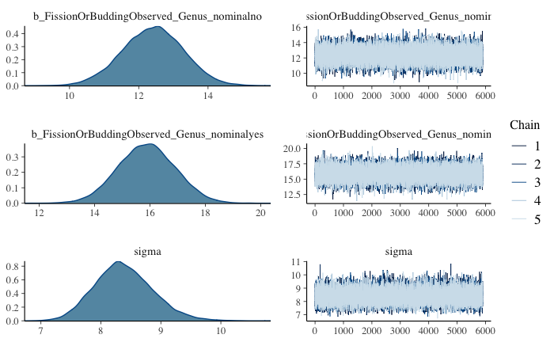

```r
#fit the model
fit_fission_cell_num<-
  brm(data = df,
      family=gaussian(), # family of model
      formula = log(cell_number) ~ 0 + FissionOrBuddingObserved_Genus_nominal,  #formula, the 0 means that there are estimates for both clonal and non-clonal, rather than relative to each other
      iter = 6000000, warmup = 100000, chains = 5,thin = 1000, cores = 5, #chain settings
      prior = prior(normal(0, 10), "b"), #defining the priors- for things in 'class b' set this prior. (can also use get_priors() and set_priors() fucncitons)
      file = 'fits/fit_FissionCellNumber' )

#### Assessing model:
<<<<<<< HEAD
plot(fit_fission_cell_num) #check that chains converged
pp_check(fit_fission_cell_num) #check the predictions
summary(fit_fission_cell_num) #summary of model
posterior_summary(fit_fission_cell_num, robust = T)
plot(conditional_effects(fit_fission_cell_num, points = TRUE, ask = F))

=======
<<<<<<< HEAD
plot(fit_fission_cell_num) #check that chains converged
```

```
Using 10 posterior draws for ppc type 'dens_overlay' by default.
```

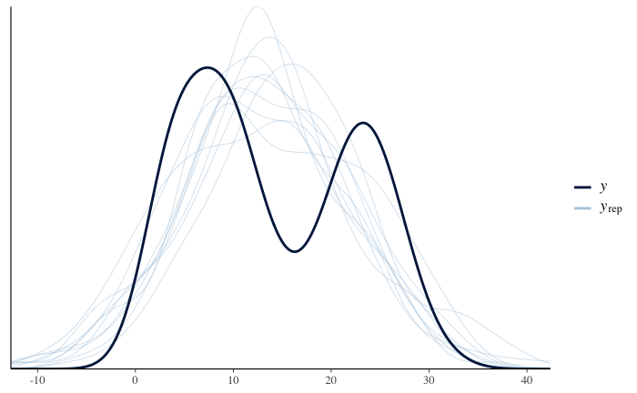

```r
pp_check(fit_fission_cell_num) #check the predictions
```

```r
summary(fit_fission_cell_num) #summary of model
```

```
 Family: gaussian
  Links: mu = identity; sigma = identity
Formula: log(cell_number) ~ 0 + FissionOrBuddingObserved_Genus_nominal
   Data: df (Number of observations: 155)
  Draws: 5 chains, each with iter = 6000; warmup = 100; thin = 1000;
         total post-warmup draws = 30

Population-Level Effects:
                                          Estimate Est.Error l-95% CI u-95% CI Rhat Bulk_ESS Tail_ESS
FissionOrBuddingObserved_Genus_nominalno     12.41      0.88    10.66    14.11 1.00    29494    29546
FissionOrBuddingObserved_Genus_nominalyes    15.88      1.03    13.86    17.89 1.00    29055    28985

Family Specific Parameters:
      Estimate Est.Error l-95% CI u-95% CI Rhat Bulk_ESS Tail_ESS
sigma     8.38      0.48     7.50     9.40 1.00    29919    29800

Draws were sampled using sampling(NUTS). For each parameter, Bulk_ESS
and Tail_ESS are effective sample size measures, and Rhat is the potential
scale reduction factor on split chains (at convergence, Rhat = 1).
```

```r
posterior_summary(fit_fission_cell_num, robust = T)
```

```
                                               Estimate Est.Error        Q2.5       Q97.5
b_FissionOrBuddingObserved_Genus_nominalno    12.418883 0.8870628   10.658512   14.106579
b_FissionOrBuddingObserved_Genus_nominalyes   15.879885 1.0370737   13.863384   17.891522
sigma                                          8.356744 0.4742410    7.501903    9.403149
lp__                                        -558.203857 1.0075698 -561.736062 -557.106225
```

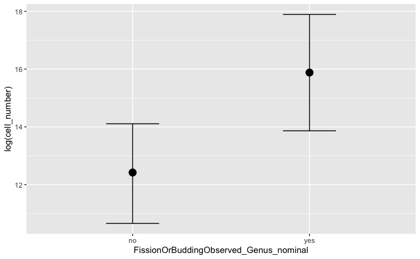

```r
plot(conditional_effects(fit_fission_cell_num, points = TRUE, ask = F))
```

```r
>>>>>>> main
hyp = hypothesis(fit_fission_cell_num,  "FissionOrBuddingObserved_Genus_nominalno > FissionOrBuddingObserved_Genus_nominalyes") #test hypothesis that there is no difference based on coefficients
hyp
plot(hyp)
```

#CKC edit: can also check convergence using gelman’s diagnostic and examining autocorrelation between samples

```r
fit_fission_cell_num$Rhat
autocor(fit_fission_cell_num)
```

[figure not shown]

#CKC edit: can also check convergence using gelman’s diagnostic and examining autocorrelation between samples

```r
gelman.diag(fit_fission_cell_num)
autocor(fit_fission_cell_num)
```

### 2.1.2 Does a single-celled bottleneck correlate with increased cell types (per cell)?

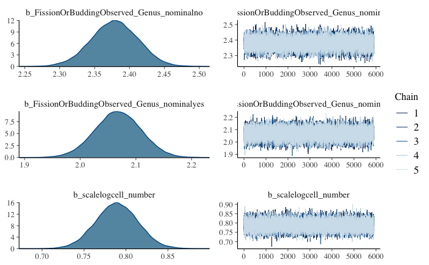

```r
#fit the model
fit_fission_cell_type<-
  brm(data = df,
      family=poisson(),
      formula = cell_types ~ 0 + FissionOrBuddingObserved_Genus_nominal + scale(log(cell_number)),  #formula, the 0 means that there are estimates for both clonal and non-clonal, rather than relative to each other
      iter = 6000000, warmup = 100000, chains = 5,thin = 1000, cores = 5, #chain settings
      prior = prior(normal(0, 10), "b"), #defining the priors- for things in 'class b' set this prior. (can also use get_priors() and set_priors() fucncitons)
      file = 'fits/fit_FissionCellType' )

<<<<<<< HEAD
plot(fit_fission_cell_type) #check that chains converged
pp_check(fit_fission_cell_type) #check the predictions
summary(fit_fission_cell_type) #summary of model
posterior_summary(fit_fission_cell_type, robust = T)
plot(conditional_effects(fit_fission_cell_type, points = TRUE, ask = F))

=======
<<<<<<< HEAD
plot(fit_fission_cell_type) #check that chains converged
```

```
Using 10 posterior draws for ppc type 'dens_overlay' by default.
```

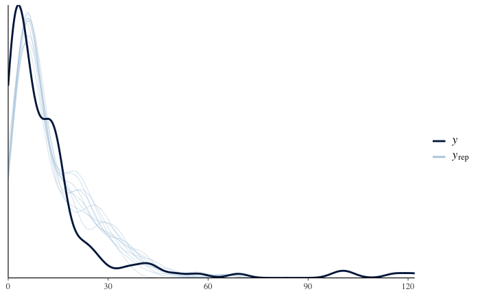

```r
pp_check(fit_fission_cell_type) #check the predictions
```

```r
summary(fit_fission_cell_type) #summary of model
```

```
 Family: poisson
  Links: mu = log
Formula: cell_types ~ 0 + FissionOrBuddingObserved_Genus_nominal + scale(log(cell_number))
   Data: df (Number of observations: 154)
  Draws: 5 chains, each with iter = 6000; warmup = 100; thin = 1000;
         total post-warmup draws = 30

Population-Level Effects:
                                          Estimate Est.Error l-95% CI u-95% CI Rhat Bulk_ESS Tail_ESS
FissionOrBuddingObserved_Genus_nominalno      2.38      0.03     2.31     2.44 1.00    29863    28120
FissionOrBuddingObserved_Genus_nominalyes     2.07      0.04     1.99     2.15 1.00    29051    29217
scalelogcell_number                           0.79      0.03     0.74     0.84 1.00    29251    29052

Draws were sampled using sampling(NUTS). For each parameter, Bulk_ESS
and Tail_ESS are effective sample size measures, and Rhat is the potential
scale reduction factor on split chains (at convergence, Rhat = 1).
```

```r
posterior_summary(fit_fission_cell_type, robust = T)
```

```
                                                 Estimate  Est.Error          Q2.5         Q97.5
b_FissionOrBuddingObserved_Genus_nominalno      2.3787467 0.03347560     2.3124781     2.4435956
b_FissionOrBuddingObserved_Genus_nominalyes     2.0677443 0.04129789     1.9861762     2.1479040
b_scalelogcell_number                           0.7889378 0.02508357     0.7397155     0.8380418
lp__                                        -1062.9584721 0.98458986 -1066.4653841 -1061.8842775
```

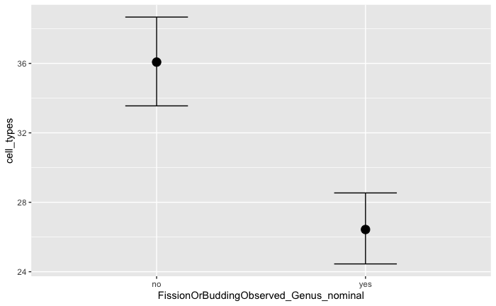

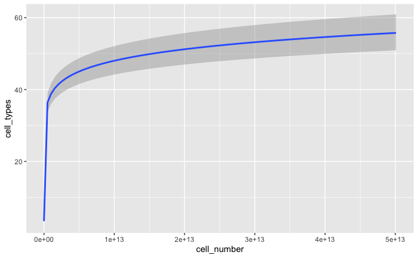

```r
plot(conditional_effects(fit_fission_cell_type, points = TRUE, ask = F))
```

```r
>>>>>>> main
hyp = hypothesis(fit_fission_cell_type,  "FissionOrBuddingObserved_Genus_nominalno > FissionOrBuddingObserved_Genus_nominalyes") #test hypothesis that there is no difference based on coefficients
hyp
plot(hyp)
```

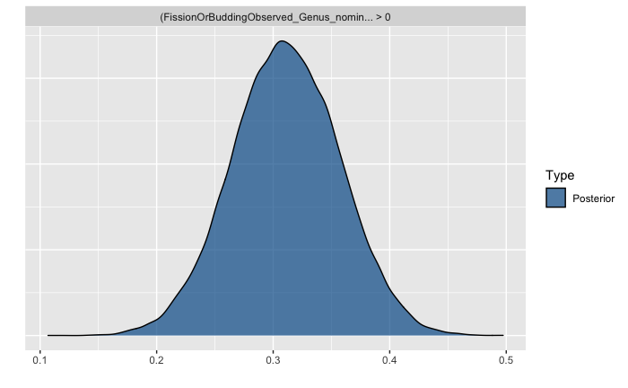